# 2021_HQM_and_NAH_data_processing

# 2021GLORIA期末報告氣候資料分析

## step 0. package 集中與路徑指定

```r
library(data.table)
library(ggplot2)
library(lubridate, warn.conflicts = FALSE) #改變時區
library(broom)
library(patchwork)# 圖組合
tccip_path <- "E:/Google 雲端硬碟/Climdata/TCCIP/1960_2019_1km_daily/"

sv_path <- "G:/我的雲端硬碟/GLORIA_個人處理/2021/analysis_data/result/"
```

## step 1. 處理datalogger資料

概述：已有完整檔案與尚未整理之檔案，將兩者資料結合 必須注意時間設定，原始資料的時間設定可能為GTM+0 ### Step 1.1 先處理尚未整理的資料

```r
log_path <- "E:/Google 雲端硬碟/GLORIA_個人處理/datalogger_org_data/"
file_n <- as.data.table(list.files(log_path))
fwrite(file_n,paste0(sv_path,"datalogger_file_name.csv"))
file_set_list <- fread(paste0(sv_path,"datalogger_file_name.csv"))
Sys.setlocale("LC_TIME", "English")
x=NULL
file_set_list[`x`]
#######組合資料
org_log <- lapply(1:nrow(file_set_list),function(x){
 file <- file_set_list[`x`]
  name <- file[,file_name]
  reg <- file[,region]
  peak <-file[,summit]
  dir_c <- file[,dir]
  rep_c <- file[,rep]
  log <- file[,type]
  dt <- fread(paste0(log_path,name))
   if (log=="hobo_1"){
      colnames(dt)[1:3] <- c("code","date","temp")
   dt[,time_st:=as.POSIXct(date,format="%m/%d/%y %I:%M:%S %p",tz ="GMT")]
   }else if(log=="hobo_2"){
      colnames(dt)[1:2] <- c("date","temp")
   dt[,time_st:=as.POSIXct(date,format="%Y/%m/%d %I:%M:%S %p",tz ="Asia/Taipei")]
   }else if(log=="mlog5"){
      dt[-1]
     colnames(dt)[1:3] <- c("code","date","temp")
    dt[,time_st:=as.POSIXct(date,format="%d.%m.%Y %H:%M:%S",tz ="GMT")]

    }
      c_dt <- data.table(code=c(1:nrow(dt)), region=reg,
                         summit=peak,
                         dir=dir_c,
                         rep=rep_c,
                         log_type=log,
                         dt[,.(date,temp,time_st)])
 return(c_dt)
})
```

### step 1,2 處理已統合的資料

```r
log_data[,yyddhh:=with_tz(time_st,tz="Asia/Taipei")]
```

```
錯誤發生在 with_tz(time_st, tz = "Asia/Taipei")：沒有這個函式 "with_tz"
```

### step 1.3 載入已統合的氣候資料，並整理成篩選前的形式

```r
w_data <- fread("E:/Google 雲端硬碟/GLORIA_個人處理/Weather_data/temp_20200809_corrected_add_date.csv")
colnames(logger_data)
Sys.setlocale("LC_TIME", "English") #Set up the time format to English.
w_data[,yyddhh:=as.POSIXct(timestamp,format="%Y-%m-%d %H:%M:%S",tz ="Asia/Taipei")+8*60*60]
w_data_r <- w_data[region %in% c("NAH","HQM"),
                   .(region,summit,direction,temperature,datalogger,yyddhh)]
w_data_r[,data_sour:="Old"]
setnames(w_data_r,c("temperature","datalogger","direction"),c("temp","log_type","dir"))
c_dt <- rbind(w_data_r,log_data,fill=TRUE)
c_dt[summit=="SMA",summit:="SMZ"]
c_dt[,year:=year(yyddhh)][,month:=month(yyddhh)][,day:=day(yyddhh)]
c_dt <- c_dt[year>2008]
for(i in unique(c_dt[,summit])){
ggplot(c_dt[summit==`i`],aes(x=yyddhh,y=temp,color=log_type))+
  geom_line()+
  facet_grid(dir~.)
ggsave(paste0(sv_path,"/plot/temp_test/",i,".jpeg"))
}
```

### step 1.4 處理異常值

以日均溫計算並挑出異常高溫日

```r
for(i in unique(d_dt[,summit])){
ggplot(d_dt[summit==`i`],aes(x=date,y=t_avg,color=log_type))+
  geom_line()+
  facet_grid(dir~.)
ggsave(paste0(sv_path,"/plot/temp_test/Daily",i,".jpeg"))
}
```

## Step 2. 整合TCCIP資料

自前一個section繼承資料： d_dt:整理後的日均溫資料 ### step 2.1. 前置資料處理

```r
#####
dt_c <- d_mix[tccip_reg,on=.(region=reg,summit=Summit,date=date)]
```

```
錯誤: 找不到物件 'd_mix'
```

### step 2.2. 回歸分析

利用TCCIP資料填補Datalogger資料空缺 首先，依照不同方位資料做回歸建模，再用預測值與數值合併 使用資料: dt_c:來自datalogger資料(t_avg,t_min,t_max)，來自tccip資料(avg_t, min_t, max_t) tccip_reg:來自tccip的資料，並已篩選地點與時間

```r
####wdata is the weather data from the combination of datalogger and ERA5
#### era5_d is the daily data from ERA5
### S is the summit code vector
dt_c <- fread(paste0(sv_path,"/daily_average_temp_data_mix_all_datalog.csv"))
dt_c[,date:=as.Date(date)]
lm_era_real <- function(wdata,era5_d,S){
  m_fr <- NULL
  w_result <- NULL
  for (i in S){
    rd <- wdata[summit==`i`]
    dir_c <- c("N","E","S","W")
    for (j in dir_c){
        r2 <- rd[dir==`j`,]
        m_avg <- lm(t_avg~avg_t,data=r2)
        m_max <- lm(t_max~max_t,data=r2)
        m_min <- lm(t_min~min_t,data=r2)
        ######save the model coefficient
        m_avg_r <-cbind(data.table(model="avg_t",
                                 summit=i,direction=j),
                      glance(m_avg)[1:6])
        m_max_r <-cbind(data.table(model="max_t",
                                 summit=i,direction=j),
                      glance(m_max)[1:6])
        m_min_r <-cbind(data.table(model="min_t",
                                 summit=i,direction=j),
                      glance(m_min)[1:6])
        #glance from the package "broom"
        m_r <- rbind(m_avg_r,m_max_r,m_min_r)
        m_fr <- rbind(m_fr,m_r)
        ################ merge the rdata and predict
        pre <- era5_d[Summit==`i`]
        pre[,t_avg_p:=predict(m_avg,pre)][
          ,t_max_p:=predict(m_max,pre)][
            ,t_min_p:=predict(m_max,pre)][
              ,dir:=j]
        t_pre <- r2[,1:7][pre,on=.(date=date,region=reg,summit=Summit,dir=dir)]

    t_pre[is.na(t_avg),c('t_avg',"t_max","t_min",'type'):=.(t_avg_p,t_max_p,t_min_p,"p")] #the 'p' mean the temp. was a predict value.
    t_pre[is.na(type),type:="r"] # the 'r' mean the temp. was a real temp..
    w_result <- rbind(w_result,t_pre)
    }#finished j loop
  } #i loop
return(list(m_fr,w_result))
}
S <- c('QNS','QSS','SMN','ZNF','SMZ','LIN')

result <- lm_era_real(dt_c,tccip_reg,S)
write.csv(result[2],paste0(sv_path,'/temp_combin_daily.csv'))
write.csv(result[1],paste0(sv_path,'/temp_model_coefficent.csv'))
```

# step 3. 合併與資料處理

概述：將計算完的資料與2020年的資料合併，再計算單一山峰的均溫。 所需資料:temp_combin_daily.csv d_mix:將所有datalogger資料統計為各山頭各方位的日均溫

```r
for(i in unique(c_bdt[,summit])){
ggplot(c_bdt[summit==`i`],aes(x=date,y=t_avg,color=type,group=group))+
  geom_line()+
  facet_grid(dir~.)+
  labs(x="Date",y="Daily temperautre average (°C)")
ggsave(paste0(sv_path,"/plot/temp_test/Daily_total_temp_",i,".jpeg"))
}
```

# step 4. 分析與作圖

## step 4.1 缺值比例計算

概述：計算資料缺值比例 以各山峰區域埋入datalogger的隔年1月1日至2020年12月31日為止的天數為基準， 統計各山峰有多少個p屬性(預測值)的溫度

```r
fwrite(dt_count_day,paste0(sv_path,"/r_temp_proportion.csv"))
```

```
錯誤發生在 fwrite(dt_count_day, paste0(sv_path, "/r_temp_proportion.csv"))：
  Permission denied: 'G:/我的雲端硬碟/GLORIA_個人處理/2021/analysis_data/result//r_temp_proportion.csv'. Failed to open existing file for writing. Do you have write permission to it? Is this Windows and does another process such as Excel have it open?
```

## step 4.2 年均溫與年雨量

概述：計算年均溫與年雨量並作圖

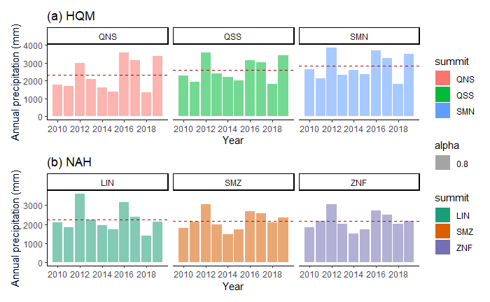

### Step 4.3 極端氣候天數計算

利用Tccip的日均溫資料做計算

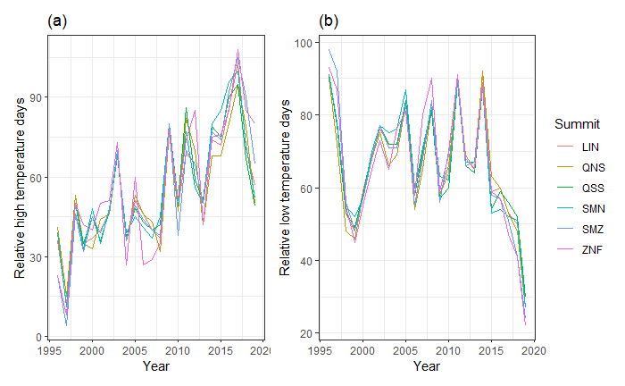

### step 4.4 季節變化

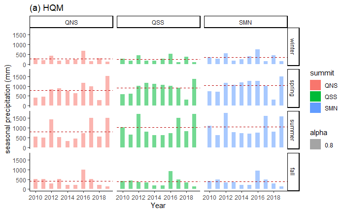